# lab3

lab 3 Yu Wu

Problem 1

```python
%matplotlib inline
import matplotlib
import matplotlib.pyplot as plt
matplotlib.rc('font', size=22)
matplotlib.rc('figure', figsize=(14, 8))
import numpy as np
import scipy as sp
import pandas as pd
from scipy import stats
from scipy.optimize import curve_fit
from multiprocessing import Pool
```

Problem 1

1.A

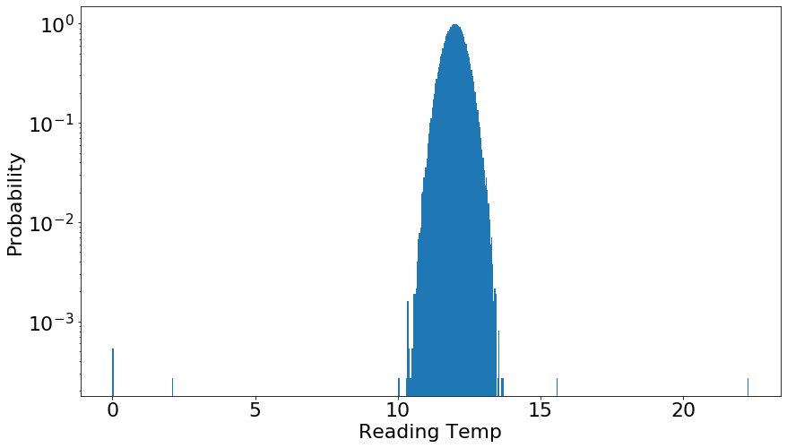

```python
mean, std_dev = 12, 0.4
dist = stats.norm(mean, std_dev)
gtempreadings = dist.rvs(100_000)
btempreadings = np.array([10., 10.3, 2.1, 0., 0., 15.6, 22.3, 12.7])
temp_readings = np.concatenate((gtempreadings, btempreadings))
plt.xlabel('Reading Temp')
plt.ylabel('Probability')
plt.hist(temp_readings, bins=600, density=True);
plt.yscale('log');
```

Question: What is the value of X-sigma does the range contains the most "good" data and the less "bad" data?

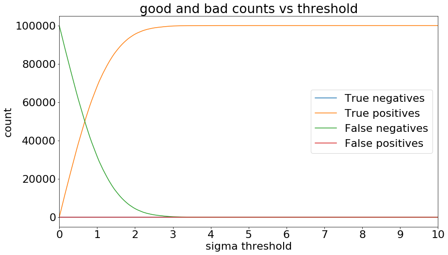

```python
def get_counts(threshold):
    cbad = temp_readings[(temp_readings < mean - threshold * std_dev) | (temp_readings > mean + threshold * std_dev)]
    cgood = temp_readings[(temp_readings > mean - threshold * std_dev) & (temp_readings < mean + threshold * std_dev)]
    tneg = len(cbad[np.isin(cbad, btempreadings)])
    tpos = len(cgood[np.isin(cgood, gtempreadings)])
    fneg = len(cbad[np.isin(cbad, gtempreadings)])
    fpos = len(cgood[np.isin(cgood, btempreadings)])
    return np.array([tneg, tpos, fneg, fpos])
thresholds = np.linspace(0, 10, 200)
with Pool() as p:
    results = np.transpose(np.array(p.map(get_counts, thresholds)))

def plot_counts(results, log_scale=False, draw_result_line=False):
    plt.title('good and bad counts vs threshold')
    plt.xlabel('sigma threshold')
    plt.ylabel('count')
    plt.plot(thresholds, results[0])
    plt.plot(thresholds, results[1])
    plt.plot(thresholds, results[2])
    plt.plot(thresholds, results[3])
    if draw_result_line:
        max_tthr = thresholds[np.argmax(results[0] + results[1])]
        min_fthr = thresholds[np.argmin(results[2] + results[3])]
        print(f"Max true: {max_tthr} sigma, Min false: {min_fthr} sigma")
        plt.axvline(max_tthr, 0, 1, color='k', linestyle='--')
        plt.axvline(min_fthr, 0, 1, color='k', linestyle='--')
    if log_scale:
        plt.yscale('log')
    plt.xlim(0, 10)
    plt.xticks(range(0, 11))
    plt.legend(['True negatives', 'True positives', 'False negatives', 'False positives'])
    if draw_result_line:
        return max_tthr, min_fthr

plot_counts(results, log_scale=False, draw_result_line=False)
```

```
a: 0.706693693321532, b: 100056.58848940166
```

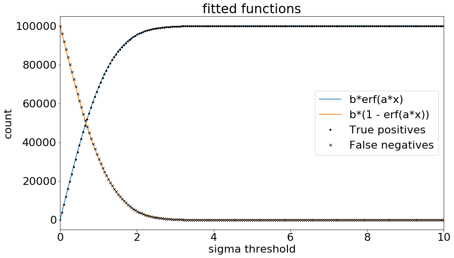

```python
from scipy.special import erf

def obj(x, a, b):
    return b*(1 - erf(a*x))
(a, b), _ = curve_fit(obj, thresholds, results[2], [0.7, 1e5])
print(f"a: {a}, b: {b}")

plt.title('fitted functions')
plt.xlabel('sigma threshold')
plt.ylabel('count')
plt.plot(thresholds, b*erf(a*thresholds))
plt.plot(thresholds, b*(1 - erf(a*thresholds)))
plt.plot(thresholds, results[1], 'ko', markersize=3)
plt.plot(thresholds, results[2], 'kx', markersize=5)
plt.xlim(0, 10)
plt.legend([f'b*erf(a*x)', 'b*(1 - erf(a*x))', 'True positives', 'False negatives']);
```

Restate my question: To maximizes the 'good' data and minimizes the 'bad' data, what is the optimal value of a threshold we need?

```
Max true: 4.874371859296483 sigma, Min false: 4.874371859296483 sigma
```

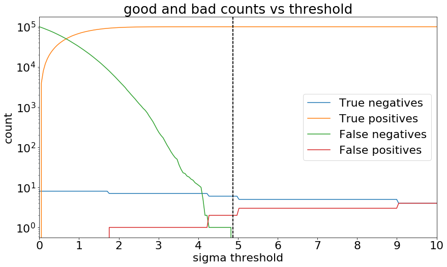

```python
max_tthr, min_fthr = plot_counts(results, log_scale = True, draw_result_line = True);
```

```python
print(f"Optimal X: {max_tthr}")
table = np.rot90(np.reshape(results[:, thresholds.searchsorted(max_tthr)], (2, 2)))
pd.DataFrame(table, ['Positive', 'Negative'], ['True', 'False'])
```

```
Optimal X: 4.874371859296483
```

|  | True | False |
| --- | --- | --- |
| Positive | 100000 | 2 |
| Negative | 6 | 0 |

1.B When threshold increases, the false negative decreases. When the threshold getting bigger, almost all data become positive. It is predictable because there's no omission.

Problem 2

2.A What is the distance away from the origin at which the 2D Gaussian background produce a position measurement that has a significance of 5-sigma?

2.B Calculate the prob of 5-sigma in standard normal distribution, then calculate the x-value in 2D Gaussian with that prob.

2.C

```python
prob = stats.norm.sf(5)
x = stats.rayleigh.isf(prob)
x
```

```
5.489079776062419
```

The angular distance required is 5.489079776062419 arc seconds from the origin.

Problem 3

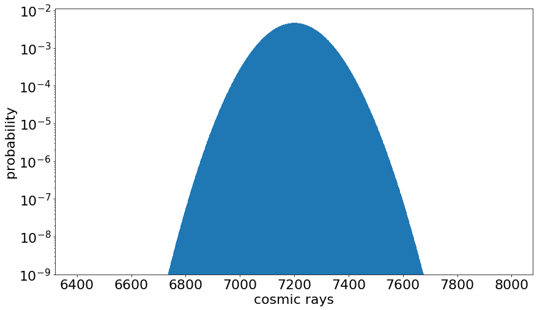

```python
dist = stats.poisson(7200)
x = np.arange(6400, 8000)
pmf = dist.pmf(x)
plt.xlabel("cosmic rays")
plt.ylabel("probability")
plt.vlines(x, 0, pmf, linewidth=1, color="C0")
plt.yscale('log')
plt.ylim(1e-9, None);
```

1. What is the probability that the data plotted above produced 6800 or less cosmic rays in 15 days?

2. Integrate the PMF of our background from 0 to 6800, and then convert it to a sigma value.

```python
prob = dist.cdf(6800)
prob
```

```
1.0133280183917768e-06
```

```python
stats.norm.ppf(prob)
```

```
-4.750747965777188
```

The significance of our moon shadow detection is -4.750747965777188 sigma.